# IE582-HW4

Tümay Kır

1/29/2021

# Different Datasets Analysis

## 1.Student Performance Data

Data Preparation: Unnecessary columns are removed and the `class` variable is created to make classification (with respect to the grade G3).

```r
data_student <-read.csv("/Users/tumay/Desktop/student-por.csv",sep = ";")
data_student <- data.table(data_student)
data_student[,31:32]<-NULL
data_student<-data_student%>%mutate(id=seq(1,nrow(data_student)))

x <-data_student[, c("id", "Mjob", "Fjob", "reason", "guardian")]
melted<- dcast(melt(x, id.vars = "id"), id ~ variable + value, fun = length)
data_student_all <-data_student[melted, on = "id"]
data_student_all[,c(9:12,32)]<-NULL
data_student_all<-data_student_all %>% mutate( class = ifelse(G3 < 10, 0, 1))

data_student_all[,"G3"]<-NULL
data_student_all<-data_student_all%>% mutate(class=as.factor(class))
head(data_student_all)
```

```
##    school sex age address famsize Pstatus Medu Fedu traveltime studytime
## 1:     GP   F  18       U     GT3       A    4    4          2         2
## 2:     GP   F  17       U     GT3       T    1    1          1         2
## 3:     GP   F  15       U     LE3       T    1    1          1         2
## 4:     GP   F  15       U     GT3       T    4    2          1         3
## 5:     GP   F  16       U     GT3       T    3    3          1         2
## 6:     GP   M  16       U     LE3       T    4    3          1         2
##    failures schoolsup famsup paid activities nursery higher internet romantic
## 1:        0       yes     no   no         no     yes    yes       no       no
## 2:        0        no    yes   no         no      no    yes      yes       no
## 3:        0       yes     no   no         no     yes    yes      yes       no
## 4:        0        no    yes   no        yes     yes    yes      yes      yes
## 5:        0        no    yes   no         no     yes    yes       no       no
## 6:        0        no    yes   no        yes     yes    yes      yes       no
##    famrel freetime goout Dalc Walc health absences Mjob_at_home Mjob_health
```

[output cut: 27 more lines]

This dataset has a class imbalance problem.

```r
table(data_student_all$class)
```

```
##
##   0   1
## 100 549
```

Parameter tuning, grid search and 10-fold cross validation processes are conducted here.

```r
set.seed(1)

control <- trainControl(method = "cv", number = 10)
# grid search
glm_grid <- expand.grid(alpha = 1, lambda = c(0, 0.5,1))
dt_grid <- expand.grid(cp = c(0, 0.005,0.01,0.05,0.1))
rf_grid <- expand.grid( mtry = c(5,6,7,8,9,10))
sgb_grid <- expand.grid(n.trees = c(10, 50, 100), shrinkage = c(0.01,0.1), interaction.depth = c(5, 10, 20), n.minobsinnode = 10)
```

The data is split to test and train data with partition rate “0.8”.

```r
training.data <- data_student_all$class%>%createDataPartition( p = 0.8, list = FALSE)
student_train <- data_student_all[training.data, ]
student_test <- data_student_all[-training.data, ]
```

Then, all the algorithms are modelled by using the function `train`.

```r
## regression
glm_model <- train(class ~ ., data = student_train, method = "glmnet",
                   trControl = control, tuneGrid = glm_grid)
## decision tree
dt_model <- train(class ~ ., data = student_train, method = "rpart",
                  trControl = control, tuneGrid = dt_grid)
## random forests
rf_model <- train(class ~ ., data = student_train, method = "rf", trControl = control,tuneGrid = rf_grid)

## stochastic gradient boosting
sgb_model <- train(class ~ ., data = student_train, method = "gbm", trControl = control, tuneGrid = sgb_grid)
```

```r
glm_model
```

```
## glmnet
##
## 520 samples
##  43 predictor
##   2 classes: '0', '1'
##
## No pre-processing
## Resampling: Cross-Validated (10 fold)
## Summary of sample sizes: 468, 468, 468, 468, 468, 468, ...
## Resampling results across tuning parameters:
##
##   lambda  Accuracy   Kappa
##   0.0     0.8500000  0.3421036
##   0.5     0.8461538  0.0000000
##   1.0     0.8461538  0.0000000
##
## Tuning parameter 'alpha' was held constant at a value of 1
## Accuracy was used to select the optimal model using the largest value.
## The final values used for the model were alpha = 1 and lambda = 0.
```

```r
dt_model
```

```
## CART
##
## 520 samples
##  43 predictor
##   2 classes: '0', '1'
##
## No pre-processing
## Resampling: Cross-Validated (10 fold)
## Summary of sample sizes: 468, 468, 468, 468, 468, 468, ...
## Resampling results across tuning parameters:
##
##   cp     Accuracy   Kappa
##   0.000  0.8403846  0.33205907
##   0.005  0.8461538  0.33507066
##   0.010  0.8442308  0.33083288
##   0.050  0.8557692  0.36376593
##   0.100  0.8442308  0.07290508
##
## Accuracy was used to select the optimal model using the largest value.
## The final value used for the model was cp = 0.05.
```

```r
rf_model
```

```
## Random Forest
##
## 520 samples
##  43 predictor
##   2 classes: '0', '1'
##
## No pre-processing
## Resampling: Cross-Validated (10 fold)
## Summary of sample sizes: 468, 468, 468, 468, 468, 468, ...
## Resampling results across tuning parameters:
##
##   mtry  Accuracy   Kappa
##    5    0.8480769  0.1237544
##    6    0.8596154  0.2100527
##    7    0.8576923  0.2077286
##    8    0.8615385  0.2544572
##    9    0.8596154  0.2577251
##   10    0.8557692  0.2525039
##
## Accuracy was used to select the optimal model using the largest value.
## The final value used for the model was mtry = 8.
```

```r
sgb_model
```

```
## Stochastic Gradient Boosting
##
## 520 samples
##  43 predictor
##   2 classes: '0', '1'
##
## No pre-processing
## Resampling: Cross-Validated (10 fold)
## Summary of sample sizes: 468, 468, 468, 468, 468, 468, ...
## Resampling results across tuning parameters:
##
##   shrinkage  interaction.depth  n.trees  Accuracy   Kappa
##   0.01        5                  10      0.8461538  0.00000000
##   0.01        5                  50      0.8461538  0.00000000
##   0.01        5                 100      0.8442308  0.05677228
##   0.01       10                  10      0.8461538  0.00000000
##   0.01       10                  50      0.8461538  0.00000000
##   0.01       10                 100      0.8423077  0.03730325
##   0.01       20                  10      0.8461538  0.00000000
##   0.01       20                  50      0.8461538  0.00000000
##   0.01       20                 100      0.8442308  0.05389980
##   0.10        5                  10      0.8423077  0.09777772
##   0.10        5                  50      0.8557692  0.31935774
##   0.10        5                 100      0.8423077  0.27462296
##   0.10       10                  10      0.8519231  0.12070910
##   0.10       10                  50      0.8615385  0.32907243
##   0.10       10                 100      0.8480769  0.32482075
##   0.10       20                  10      0.8480769  0.11644014
##   0.10       20                  50      0.8461538  0.26498330
##   0.10       20                 100      0.8365385  0.25303420
##
## Tuning parameter 'n.minobsinnode' was held constant at a value of 10
## Accuracy was used to select the optimal model using the largest value.
## The final values used for the model were n.trees = 50, interaction.depth =
##  10, shrinkage = 0.1 and n.minobsinnode = 10.
```

```r
best_tune<-data.table(glm_model$bestTune,
dt_model$bestTune,
rf_model$bestTune,
sgb_model$bestTune)
best_tune
```

```
##    alpha lambda   cp mtry n.trees interaction.depth shrinkage n.minobsinnode
## 1:     1      0 0.05    8      50                10       0.1             10
```

According to the table below, the most accurate models are obtained by RandomForests and Gradient Boosting.

```r
data.table(glm=max(glm_model$results$Accuracy),
dt=max(dt_model$results$Accuracy),
rf=max(rf_model$results$Accuracy),
sgb=max(sgb_model$results$Accuracy))
```

```
##     glm        dt        rf       sgb
## 1: 0.85 0.8557692 0.8615385 0.8615385
```

```r
model_list <- list(Glmnet=glm_model,DT=dt_model,Forest =rf_model,SGBM =sgb_model)
rValues <- resamples(model_list)
rValues$values
```

```
##    Resample Glmnet~Accuracy Glmnet~Kappa DT~Accuracy  DT~Kappa Forest~Accuracy
## 1    Fold01       0.7884615   0.04026846   0.8461538 0.4090909       0.8846154
## 2    Fold02       0.8846154   0.50632911   0.8269231 0.2994012       0.8846154
## 3    Fold03       0.8653846   0.30534351   0.8461538 0.2571429       0.8461538
## 4    Fold04       0.8461538   0.25714286   0.8653846 0.3892617       0.8461538
## 5    Fold05       0.8846154   0.36065574   0.8653846 0.4550898       0.8653846
## 6    Fold06       0.8269231   0.29940120   0.8269231 0.2147651       0.8846154
## 7    Fold07       0.9038462   0.50381679   0.8461538 0.2571429       0.8653846
## 8    Fold08       0.8461538   0.40909091   0.9038462 0.5038168       0.8269231
## 9    Fold09       0.8461538   0.40909091   0.8461538 0.4090909       0.8653846
## 10   Fold10       0.8076923   0.32989691   0.8846154 0.4428571       0.8461538
##    Forest~Kappa SGBM~Accuracy SGBM~Kappa
## 1     0.3606557     0.8846154 0.50632911
## 2     0.5063291     0.9038462 0.56375839
## 3     0.0000000     0.8846154 0.44285714
## 4     0.1475410     0.8653846 0.19469027
## 5     0.3053435     0.8461538 0.34177215
## 6     0.3606557     0.8653846 0.30534351
## 7     0.3053435     0.8653846 0.45508982
## 8     0.1068702     0.8076923 0.07142857
## 9     0.1946903     0.8653846 0.19469027
## 10    0.2571429     0.8269231 0.21476510
```

Now, by using these models predictions are made on the test data set.Then, their performances are compared.

```r
pred_student_glm <- predict(glm_model,student_test,type="prob")
pred_student_dt <- predict(dt_model,student_test,type="prob")
pred_student_rf <- predict(rf_model,student_test,type="prob")
pred_student_sgb <-predict(sgb_model,student_test,type="prob")

Model_Perf_Student <- data.table(
  glm_roc = roc(student_test$class,pred_student_glm[,1])$auc,
  dt_roc = roc(student_test$class,pred_student_dt[,1])$auc,
  rf_roc =roc(student_test$class,pred_student_rf[,1])$auc,
  sgb_roc = roc(student_test$class,pred_student_sgb[,1])$auc
  )
Model_Perf_Student
```

```
##      glm_roc    dt_roc    rf_roc   sgb_roc
## 1: 0.7073394 0.3912844 0.7690367 0.7605505
```

As we can see, rf has the best performance among them. Decision tree has relatively bad performance than others.It might result from its hyperparameters or the dataset itself.

```r
confusionMatrix(student_test$class, predict(rf_model, student_test))
```

```
## Confusion Matrix and Statistics
##
##           Reference
## Prediction   0   1
##          0   4  16
##          1   4 105
##
##                Accuracy : 0.845
##                  95% CI : (0.7708, 0.9027)
##     No Information Rate : 0.938
##     P-Value [Acc > NIR] : 0.99995
##
##                   Kappa : 0.2163
##
##  Mcnemar's Test P-Value : 0.01391
##
##             Sensitivity : 0.50000
##             Specificity : 0.86777
##          Pos Pred Value : 0.20000
##          Neg Pred Value : 0.96330
##              Prevalence : 0.06202
##          Detection Rate : 0.03101
##    Detection Prevalence : 0.15504
##       Balanced Accuracy : 0.68388
##
##        'Positive' Class : 0
##
```

This plot shows that how the accuracy changed over selected predictors (for Random Forests).

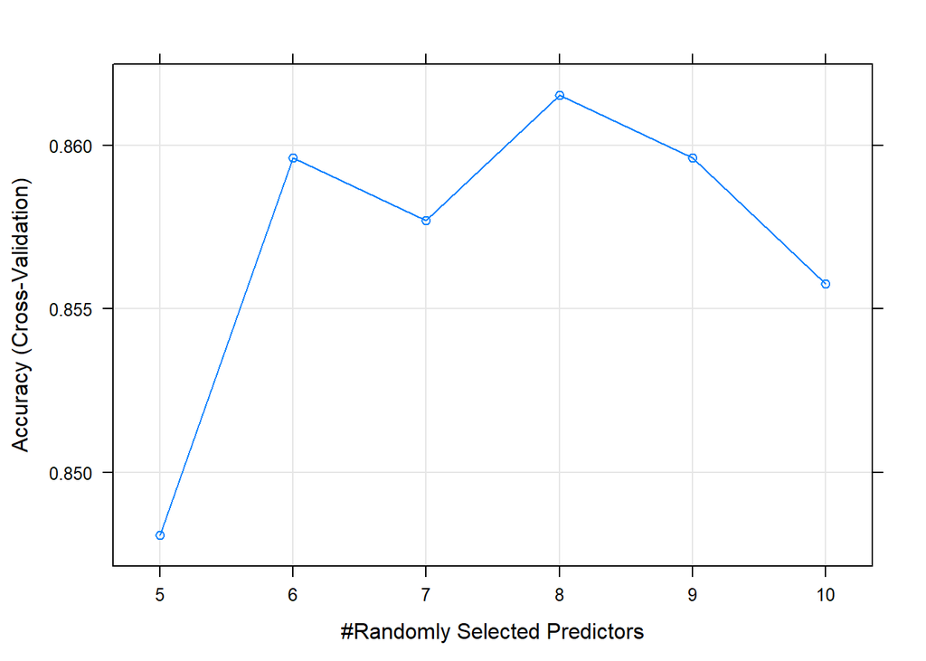

```r
plot(rf_model)
```

# 2.Cardiotocography Data

Data preparation: The response (y) data for this dataset has 3 classes: 1, 2, or 3 in `NSP` column. It is a multiclass classification problem.

```r
data_cardio<-read_excel("C:/Users/tumay/Desktop/Cardiotocography.xls")
data_cardio<-data.table(data_cardio)
data_cardio[,c(1,2,3,18,39)]<-NULL

data_cardio<-data_cardio[complete.cases(data_cardio), ]
data_cardio$NSP<-as.factor(data_cardio$NSP)
head(data_cardio)
```

```
##      b    e LBE  LB AC FM UC ASTV MSTV ALTV MLTV DL DS DP Width Min Max Nmax
## 1: 240  357 120 120  0  0  0   73  0.5   43  2.4  0  0  0    64  62 126    2
## 2:   5  632 132 132  4  0  4   17  2.1    0 10.4  2  0  0   130  68 198    6
## 3: 177  779 133 133  2  0  5   16  2.1    0 13.4  2  0  0   130  68 198    5
## 4: 411 1192 134 134  2  0  6   16  2.4    0 23.0  2  0  0   117  53 170   11
## 5: 533 1147 132 132  4  0  5   16  2.4    0 19.9  0  0  0   117  53 170    9
## 6:   0  953 134 134  1  0 10   26  5.9    0  0.0  9  0  2   150  50 200    5
##    Nzeros Mode Mean Median Variance Tendency A B C D E AD DE LD FS SUSP NSP
## 1:      0  120  137    121       73        1 0 0 0 0 0  0  0  0  1    0   2
## 2:      1  141  136    140       12        0 0 0 0 0 0  1  0  0  0    0   1
## 3:      1  141  135    138       13        0 0 0 0 0 0  1  0  0  0    0   1
## 4:      0  137  134    137       13        1 0 0 0 0 0  1  0  0  0    0   1
## 5:      0  137  136    138       11        1 0 1 0 0 0  0  0  0  0    0   1
## 6:      3   76  107    107      170        0 0 0 0 0 0  0  0  1  0    0   3
```

Test and train splitting

```r
trainIndex <- createDataPartition(data_cardio$NSP, p = 0.8, list = FALSE)
data_cardio_train <- data_cardio[trainIndex, ]
data_cardio_test <- data_cardio[-trainIndex, ]
```

```r
glm_model <- train(NSP ~ ., data = data_cardio_train, method = "glmnet",
                   trControl = control, tuneGrid = glm_grid, family = "multinomial")

dt_model <- train(NSP ~ ., data = data_cardio_train, method = "rpart",
                  trControl = control, tuneGrid = dt_grid)

rf_model <- train(NSP ~ ., data = data_cardio_train, method = "rf", trControl = control,
                  tuneGrid = rf_grid, family = "multinomial")

sgb_model <- train(NSP ~ ., data = data_cardio_train, method = "gbm", trControl = control,
                   tuneGrid = sgb_grid)
```

Accuracy of models

```r
glm_model
```

```
## glmnet
##
## 1701 samples
##   34 predictor
##    3 classes: '1', '2', '3'
##
## No pre-processing
## Resampling: Cross-Validated (10 fold)
## Summary of sample sizes: 1530, 1530, 1530, 1530, 1532, 1532, ...
## Resampling results across tuning parameters:
##
##   lambda  Accuracy   Kappa
##   0.0     0.9864841  0.9633786
##   0.5     0.7783753  0.0000000
##   1.0     0.7783753  0.0000000
##
## Tuning parameter 'alpha' was held constant at a value of 1
## Accuracy was used to select the optimal model using the largest value.
## The final values used for the model were alpha = 1 and lambda = 0.
```

```r
dt_model
```

```
## CART
##
## 1701 samples
##   34 predictor
##    3 classes: '1', '2', '3'
##
## No pre-processing
## Resampling: Cross-Validated (10 fold)
## Summary of sample sizes: 1531, 1530, 1531, 1531, 1530, 1530, ...
## Resampling results across tuning parameters:
##
##   cp     Accuracy   Kappa
##   0.000  0.9882489  0.9679229
##   0.005  0.9876607  0.9662233
##   0.010  0.9835430  0.9539037
##   0.050  0.9835430  0.9539037
##   0.100  0.9835430  0.9539037
##
## Accuracy was used to select the optimal model using the largest value.
## The final value used for the model was cp = 0.
```

```r
rf_model
```

```
## Random Forest
##
## 1701 samples
##   34 predictor
##    3 classes: '1', '2', '3'
##
## No pre-processing
## Resampling: Cross-Validated (10 fold)
## Summary of sample sizes: 1532, 1531, 1531, 1531, 1531, 1531, ...
## Resampling results across tuning parameters:
##
##   mtry  Accuracy   Kappa
##    5    0.9882419  0.9676565
##    6    0.9882419  0.9676565
##    7    0.9882419  0.9676565
##    8    0.9882419  0.9676565
##    9    0.9882419  0.9676565
##   10    0.9882419  0.9676565
##
## Accuracy was used to select the optimal model using the largest value.
## The final value used for the model was mtry = 5.
```

```r
sgb_model
```

```
## Stochastic Gradient Boosting
##
## 1701 samples
##   34 predictor
##    3 classes: '1', '2', '3'
##
## No pre-processing
## Resampling: Cross-Validated (10 fold)
## Summary of sample sizes: 1530, 1530, 1531, 1531, 1530, 1530, ...
## Resampling results across tuning parameters:
##
##   shrinkage  interaction.depth  n.trees  Accuracy   Kappa
##   0.01        5                  10      0.9835394  0.9542624
##   0.01        5                  50      0.9835394  0.9542624
##   0.01        5                 100      0.9835394  0.9542624
##   0.01       10                  10      0.9835394  0.9542624
##   0.01       10                  50      0.9835394  0.9542624
##   0.01       10                 100      0.9858924  0.9610410
##   0.01       20                  10      0.9835394  0.9542624
##   0.01       20                  50      0.9835394  0.9542624
##   0.01       20                 100      0.9853042  0.9593675
##   0.10        5                  10      0.9835394  0.9542624
##   0.10        5                  50      0.9876572  0.9661820
##   0.10        5                 100      0.9882454  0.9678378
##   0.10       10                  10      0.9858993  0.9609387
##   0.10       10                  50      0.9888302  0.9693487
##   0.10       10                 100      0.9888371  0.9694441
##   0.10       20                  10      0.9841242  0.9559672
##   0.10       20                  50      0.9876468  0.9660113
##   0.10       20                 100      0.9870620  0.9645034
##
## Tuning parameter 'n.minobsinnode' was held constant at a value of 10
## Accuracy was used to select the optimal model using the largest value.
## The final values used for the model were n.trees = 100, interaction.depth =
##  10, shrinkage = 0.1 and n.minobsinnode = 10.
```

Stochastic Gradient Boosting algorithm has the highest accuracy for this data set.

```r
data.table(glm=max(glm_model$results$Accuracy),
dt=max(dt_model$results$Accuracy),
rf=max(rf_model$results$Accuracy),
sgb=max(sgb_model$results$Accuracy))
```

```
##          glm        dt        rf       sgb
## 1: 0.9864841 0.9882489 0.9882419 0.9888371
```

```r
model_list <- list(Glmnet=glm_model,DT=dt_model,Forest =rf_model,SGBM =sgb_model)
rValues <- resamples(model_list)
rValues$values
```

```
##    Resample Glmnet~Accuracy Glmnet~Kappa DT~Accuracy  DT~Kappa Forest~Accuracy
## 1    Fold01       0.9883041    0.9676198   0.9882353 0.9688645       0.9822485
## 2    Fold02       0.9649123    0.9086538   0.9824561 0.9519258       0.9882353
## 3    Fold03       0.9941520    0.9839753   0.9882353 0.9668810       0.9764706
## 4    Fold04       0.9941520    0.9839753   0.9882353 0.9688645       0.9882353
## 5    Fold05       0.9763314    0.9356925   0.9824561 0.9519258       0.9941176
## 6    Fold06       0.9881657    0.9675375   0.9941520 0.9843234       0.9941176
## 7    Fold07       1.0000000    1.0000000   1.0000000 1.0000000       0.9941176
## 8    Fold08       0.9823529    0.9518686   0.9940828 0.9837547       0.9881657
## 9    Fold09       0.9882353    0.9675820   0.9881657 0.9675375       0.9825581
## 10   Fold10       0.9882353    0.9668810   0.9764706 0.9351516       0.9941520
##    Forest~Kappa SGBM~Accuracy SGBM~Kappa
## 1     0.9502209     0.9941520  0.9839753
## 2     0.9675820     0.9883041  0.9683333
## 3     0.9351516     0.9882353  0.9682362
## 4     0.9682362     0.9764706  0.9377289
## 5     0.9839562     0.9883041  0.9676198
## 6     0.9836160     0.9824561  0.9509232
## 7     0.9839562     0.9881657  0.9671653
## 8     0.9668432     1.0000000  1.0000000
## 9     0.9530269     0.9941176  0.9836160
## 10    0.9839753     0.9881657  0.9668432
```

Random Forsts algorithm has the best roc value which indicates the usefulness of the test.

```r
pred_cardio_glm <- predict(glm_model,data_cardio_test,type="prob")
pred_cardio_dt <- predict(dt_model,data_cardio_test,type="prob")
pred_cardio_rf <- predict(rf_model,data_cardio_test,type="prob")
pred_cardio_sgb <-predict(sgb_model,data_cardio_test,type="prob")


Model_Perf_Cardio <- data.table(
  glm_roc = multiclass.roc(data_cardio_test$NSP,pred_cardio_glm)$auc,
  dt_roc = multiclass.roc(data_cardio_test$NSP,pred_cardio_dt)$auc,
  rf_roc =multiclass.roc(data_cardio_test$NSP,pred_cardio_rf)$auc,
  sgb_roc = multiclass.roc(data_cardio_test$NSP,pred_cardio_sgb)$auc
)

Model_Perf_Cardio
```

```
##      glm_roc    dt_roc    rf_roc   sgb_roc
## 1: 0.9902794 0.9881373 0.9977567 0.9977089
```

In the plot below, the shrinkage (learning rate) defines the steps taken in the gradient descent of boosting, as boosting will do a convergence toward Y. When the depth is 10 and shrinkage=0.1, the most accurate results can be obtained.

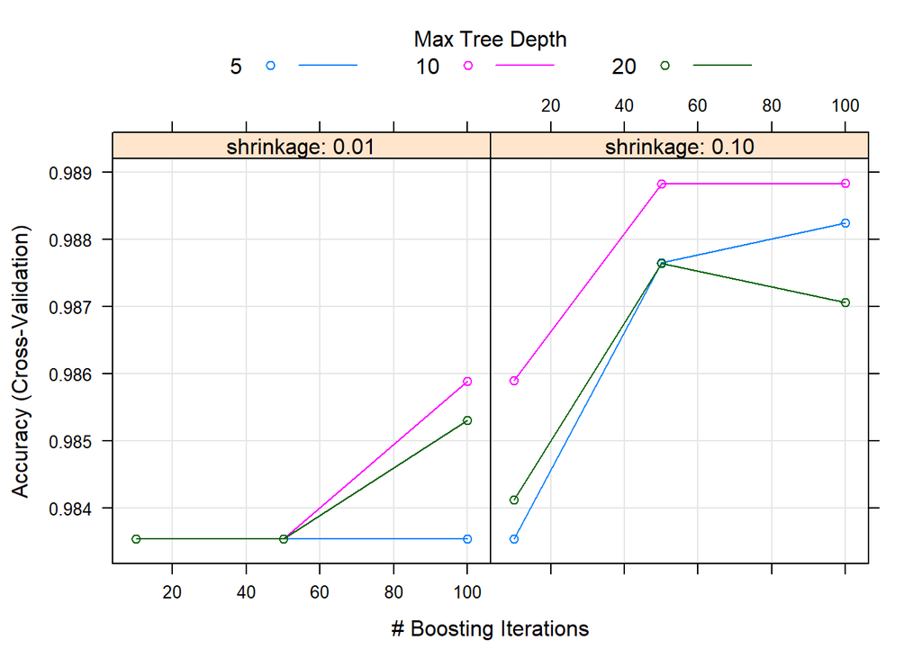

```r
plot(sgb_model)
```

```r
confusionMatrix(data_cardio_test$NSP, predict(sgb_model, data_cardio_test))
```

```
## Confusion Matrix and Statistics
##
##           Reference
## Prediction   1   2   3
##          1 331   0   0
##          2   5  53   1
##          3   0   0  35
##
## Overall Statistics
##
##                Accuracy : 0.9859
##                  95% CI : (0.9695, 0.9948)
##     No Information Rate : 0.7906
##     P-Value [Acc > NIR] : < 2.2e-16
##
##                   Kappa : 0.9608
##
##  Mcnemar's Test P-Value : NA
##
## Statistics by Class:
##
##                      Class: 1 Class: 2 Class: 3
## Sensitivity            0.9851   1.0000  0.97222
## Specificity            1.0000   0.9839  1.00000
## Pos Pred Value         1.0000   0.8983  1.00000
## Neg Pred Value         0.9468   1.0000  0.99744
## Prevalence             0.7906   0.1247  0.08471
## Detection Rate         0.7788   0.1247  0.08235
## Detection Prevalence   0.7788   0.1388  0.08235
## Balanced Accuracy      0.9926   0.9919  0.98611
```

## 3.Employee Attrition and Performance Data

Again, the same steps for this data set.

```r
data_employee<-read.csv("C:/Users/tumay/Desktop/employee.csv")
data_employee<-data.table(data_employee)
data_employee$Over18<-NULL
```

```r
trainIndex <- createDataPartition(data_employee$Attrition, p = 0.8, list = FALSE)
data_employee_train <- data_employee[trainIndex, ]
data_employee_test <- data_employee[-trainIndex, ]
```

```r
set.seed(1)
n <- createMultiFolds(data_employee_train$Attrition,k=10,times = 1)

control<-trainControl(method="cv",verboseIter=TRUE,summaryFunction=twoClassSummary,classProbs=TRUE,savePredictions=TRUE,index=n,allowParallel=TRUE)


grid_glmnet <- expand.grid(alpha= 1, lambda = c(seq(0.00001,0.001,length=6)))
grid_dt <- expand.grid(cp=c(0.01,0.005,0.1,0.05))
grid_rf <- expand.grid(n.trees=500, mtry = c(5:8))
grid_sgb <- expand.grid(interaction.depth=c(1,3,5), n.trees = (3:5)*50,shrinkage=c(0.05,0.01, 0.005), n.minobsinnode=10)
```

```r
glm_model<-train(Attrition~.,data=data_employee_train,method="glmnet",tuneGrid=grid_glmnet,trControl=control)
glm_model
```

```
## glmnet
##
## 1177 samples
##   33 predictor
##    2 classes: 'No', 'Yes'
##
## No pre-processing
## Resampling: Cross-Validated (10 fold)
## Summary of sample sizes: 1059, 1059, 1059, 1059, 1059, 1060, ...
## Resampling results across tuning parameters:
##
##   lambda    ROC        Sens       Spec
##   0.000010  0.8187710  0.9645743  0.4368421
##   0.000208  0.8211622  0.9666048  0.4368421
##   0.000406  0.8240390  0.9676149  0.4368421
##   0.000604  0.8248381  0.9686250  0.4315789
##   0.000802  0.8246759  0.9686250  0.4315789
##   0.001000  0.8249433  0.9696351  0.4368421
##
## Tuning parameter 'alpha' was held constant at a value of 1
## ROC was used to select the optimal model using the largest value.
## The final values used for the model were alpha = 1 and lambda = 0.001.
```

```r
set.seed(42)
dt_model_a <- train(Attrition~., data=data_employee_train,method ="rpart",tuneGrid = grid_dt,trControl=control, control = rpart.control(minbucket=c(1)))
set.seed(42)
dt_model_b <- train(Attrition~., data=data_employee_train,method ="rpart",tuneGrid = grid_dt,trControl=control, control = rpart.control(minbucket=c(5)))
set.seed(42)
dt_model_c <- train(Attrition~., data=data_employee_train,method ="rpart",tuneGrid = grid_dt,trControl=control, control = rpart.control(minbucket=c(10)))
set.seed(42)
dt_model_d <- train(Attrition~., data=data_employee_train,method ="rpart",tuneGrid = grid_dt,trControl=control, control = rpart.control(minbucket=c(15)))
dt_model_a
```

```
## CART
##
## 1177 samples
##   33 predictor
##    2 classes: 'No', 'Yes'
##
## No pre-processing
## Resampling: Cross-Validated (10 fold)
## Summary of sample sizes: 1059, 1059, 1059, 1059, 1059, 1060, ...
## Resampling results across tuning parameters:
##
##   cp     ROC        Sens       Spec
##   0.005  0.5271450  0.8895589  0.28947368
##   0.010  0.6097283  0.9402391  0.23684211
##   0.050  0.5195700  0.9949289  0.01578947
##   0.100  0.5000000  1.0000000  0.00000000
##
## ROC was used to select the optimal model using the largest value.
## The final value used for the model was cp = 0.01.
```

```r
dt_model_b ## has the best roc value
```

```
## CART
##
## 1177 samples
##   33 predictor
##    2 classes: 'No', 'Yes'
##
## No pre-processing
## Resampling: Cross-Validated (10 fold)
## Summary of sample sizes: 1059, 1059, 1059, 1059, 1059, 1060, ...
## Resampling results across tuning parameters:
##
##   cp     ROC        Sens       Spec
##   0.005  0.6737531  0.9219233  0.26315789
##   0.010  0.6569283  0.9412080  0.22631579
##   0.050  0.5195700  0.9949289  0.01578947
##   0.100  0.5000000  1.0000000  0.00000000
##
## ROC was used to select the optimal model using the largest value.
## The final value used for the model was cp = 0.005.
```

```r
dt_model_c
```

```
## CART
##
## 1177 samples
##   33 predictor
##    2 classes: 'No', 'Yes'
##
## No pre-processing
## Resampling: Cross-Validated (10 fold)
## Summary of sample sizes: 1059, 1059, 1059, 1059, 1059, 1060, ...
## Resampling results across tuning parameters:
##
##   cp     ROC        Sens       Spec
##   0.005  0.6611466  0.9280973  0.26315789
##   0.010  0.6652413  0.9473201  0.20526316
##   0.050  0.5195700  0.9949289  0.01578947
##   0.100  0.5000000  1.0000000  0.00000000
##
## ROC was used to select the optimal model using the largest value.
## The final value used for the model was cp = 0.01.
```

```r
dt_model_d
```

```
## CART
##
## 1177 samples
##   33 predictor
##    2 classes: 'No', 'Yes'
##
## No pre-processing
## Resampling: Cross-Validated (10 fold)
## Summary of sample sizes: 1059, 1059, 1059, 1059, 1059, 1060, ...
## Resampling results across tuning parameters:
##
##   cp     ROC        Sens       Spec
##   0.005  0.6608846  0.9422593  0.28947368
##   0.010  0.6601607  0.9452896  0.25789474
##   0.050  0.5195700  0.9949289  0.01578947
##   0.100  0.5000000  1.0000000  0.00000000
##
## ROC was used to select the optimal model using the largest value.
## The final value used for the model was cp = 0.005.
```

```r
set.seed(42)
rf_model <- train(Attrition ~., data=data_employee_train, method="rf", tuneGrid= rf_grid, trControl= control)
rf_model
```

```
## Random Forest
##
## 1177 samples
##   33 predictor
##    2 classes: 'No', 'Yes'
##
## No pre-processing
## Resampling: Cross-Validated (10 fold)
## Summary of sample sizes: 1059, 1059, 1059, 1059, 1059, 1060, ...
## Resampling results across tuning parameters:
##
##   mtry  ROC        Sens       Spec
##    5    0.8020915  0.9959390  0.1421053
##    6    0.8025792  0.9928881  0.1263158
##    7    0.8017896  0.9898475  0.1368421
##    8    0.8022494  0.9908679  0.1368421
##    9    0.7962162  0.9908576  0.1631579
##   10    0.8026728  0.9888477  0.1526316
##
## ROC was used to select the optimal model using the largest value.
## The final value used for the model was mtry = 10.
```

```r
set.seed(42)
sgb_model <- train(Attrition ~., data=data_employee_train, method="gbm", tuneGrid= grid_sgb, trControl= control)
```

```r
sgb_model
```

```
## Stochastic Gradient Boosting
##
## 1177 samples
##   33 predictor
##    2 classes: 'No', 'Yes'
##
## No pre-processing
## Resampling: Cross-Validated (10 fold)
## Summary of sample sizes: 1059, 1059, 1059, 1059, 1059, 1060, ...
## Resampling results across tuning parameters:
##
##   shrinkage  interaction.depth  n.trees  ROC        Sens       Spec
##   0.005      1                  150      0.7412083  1.0000000  0.00000000
##   0.005      1                  200      0.7463727  1.0000000  0.00000000
##   0.005      1                  250      0.7497366  1.0000000  0.00000000
##   0.005      3                  150      0.7635612  1.0000000  0.02105263
##   0.005      3                  200      0.7702904  0.9989899  0.03684211
##   0.005      3                  250      0.7733810  0.9979798  0.05789474
##   0.005      5                  150      0.7814889  1.0000000  0.02105263
##   0.005      5                  200      0.7861906  0.9979798  0.05789474
##   0.005      5                  250      0.7886827  0.9979798  0.08421053
##   0.010      1                  150      0.7558027  1.0000000  0.00000000
##   0.010      1                  200      0.7638837  1.0000000  0.02105263
##   0.010      1                  250      0.7706254  0.9989796  0.05263158
##   0.010      3                  150      0.7768561  0.9979798  0.08947368
##   0.010      3                  200      0.7836138  0.9959493  0.11578947
##   0.010      3                  250      0.7903379  0.9939188  0.13684211
##   0.010      5                  150      0.7861428  0.9959596  0.12105263
##   0.010      5                  200      0.7947059  0.9949392  0.13157895
##   0.010      5                  250      0.7986552  0.9929087  0.15789474
##   0.050      1                  150      0.8131742  0.9939085  0.15789474
##   0.050      1                  200      0.8177120  0.9898578  0.21578947
##   0.050      1                  250      0.8252173  0.9868172  0.25263158
##   0.050      3                  150      0.8077000  0.9837765  0.23684211
##   0.050      3                  200      0.8044993  0.9837765  0.25789474
##   0.050      3                  250      0.8107211  0.9807462  0.29473684
##   0.050      5                  150      0.8103061  0.9817563  0.28421053
##   0.050      5                  200      0.8096149  0.9787260  0.31052632
##   0.050      5                  250      0.8109706  0.9797464  0.31052632
##
## Tuning parameter 'n.minobsinnode' was held constant at a value of 10
## ROC was used to select the optimal model using the largest value.
## The final values used for the model were n.trees = 250, interaction.depth =
##  1, shrinkage = 0.05 and n.minobsinnode = 10.
```

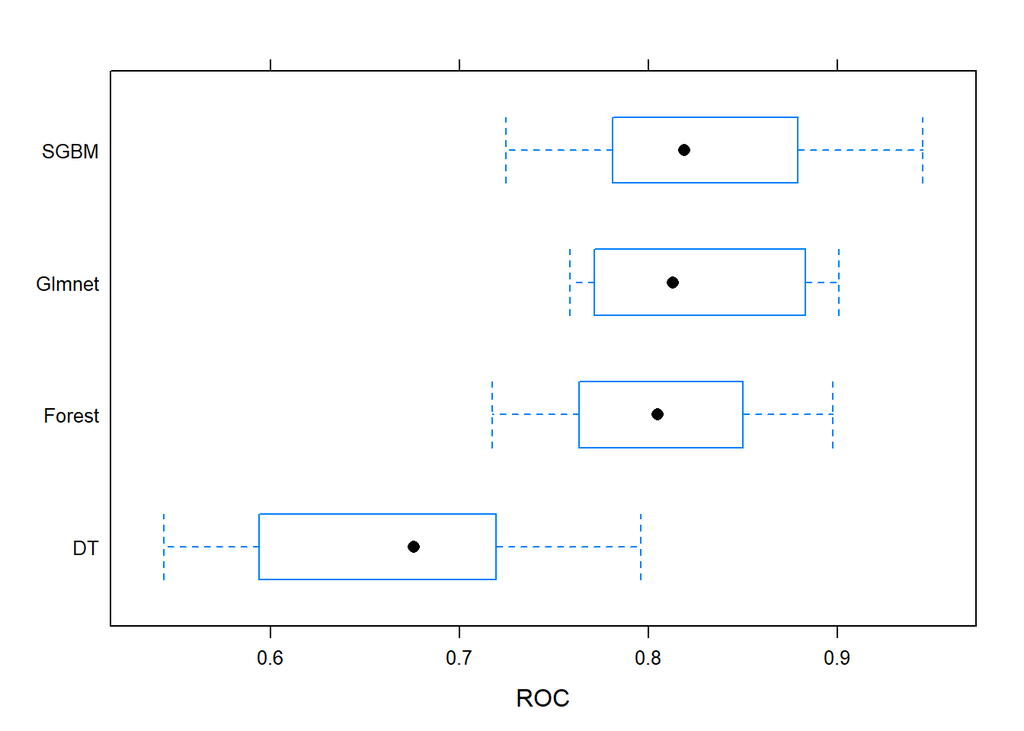

```r
model_list_employee <- list(Glmnet=glm_model, DT=dt_model_c, Forest = rf_model, SGBM = sgb_model)
r <- resamples(model_list_employee)
bwplot(r,metric ="ROC")
```

```r
pred_employee_glm <- predict(glm_model,data_employee_test,type="prob")
pred_employee_dt <- predict(dt_model_c,data_employee_test,type="prob")
predn_employee_rf <- predict(rf_model,data_employee_test,type="prob")
pred_employee_sgb <- predict(sgb_model,data_employee_test,type="prob")


Test_Performances_employee <- data.table(
  glm_roc = roc(data_employee_test$Attrition,pred_employee_glm[,1])$auc,
  dt_roc = roc(data_employee_test$Attrition,pred_employee_dt[,1])$auc,
  rf_roc =roc(data_employee_test$Attrition,predn_employee_rf[,1])$auc,
  sgb_roc = roc(data_employee_test$Attrition,pred_employee_sgb[,1])$auc
)

Test_Performances_employee
```

```
##      glm_roc    dt_roc    rf_roc   sgb_roc
## 1: 0.8433662 0.7574382 0.8080782 0.8381768
```

PRA has the best roc value. It means glm_model has the best accuracy are under the ROC curve. (A measure of 1 would indicate a perfect model.)

## 4. Crime and Communities Data

Data preparation

```r
data_communities<-read.table("~/communities.data", sep = "\t",dec=",")
data_communities<-do.call(rbind, strsplit(data_communities$V1, ','))
data_communities<-data.table(data_communities)
data_communities<-data_communities[,6:128]
data_communities<-data_communities[,-c(97:113)]
data_communities<-data_communities[,-c(100:105)]

colnames(data_communities)<-c("population",
                              "householdsize",
                              "racepctblack",
                              "racePctWhite",
                              "racePctAsian",
                              "racePctHisp",
                              "agePct12t21",
                              "agePct12t29",
                              "agePct16t24",
                              "agePct65up",
                              "numbUrban",
                              "pctUrban",
                              "medIncome",
                              "pctWWage",
                              "pctWFarmSelf",
                              "pctWInvInc",
                              "pctWSocSec",
                              "pctWPubAsst",
                              "pctWRetire",
                              "medFamInc",
                              "perCapInc",
                              "whitePerCap",
                              "blackPerCap",
                              "indianPerCap",
                              "AsianPerCap",
                              "OtherPerCap",
                              "HispPerCap",
                              "NumUnderPov",
                              "PctPopUnderPov",
                              "PctLess9thGrade",
                              "PctNotHSGrad",
                              "PctBSorMore",
                              "PctUnemployed",
                              "PctEmploy",
                              "PctEmplManu",
                              "PctEmplProfServ",
                              "PctOccupManu",
                              "PctOccupMgmtProf",
                              "MalePctDivorce",
                              "MalePctNevMarr",
                              "FemalePctDiv",
                              "TotalPctDiv",
                              "PersPerFam",
                              "PctFam2Par",
                              "PctKids2Par",
                              "PctYoungKids2Par",
                              "PctTeen2Par",
                              "PctWorkMomYoungKids",
                              "PctWorkMom",
                              "NumIlleg",
                              "PctIlleg",
                              "NumImmig",
                              "PctImmigRecent",
                              "PctImmigRec5",
                              "PctImmigRec8",
                              "PctImmigRec10",
                              "PctRecentImmig",
                              "PctRecImmig5",
                              "PctRecImmig8",
                              "PctRecImmig10",
                              "PctSpeakEnglOnly",
                              "PctNotSpeakEnglWell",
                              "PctLargHouseFam",
                              "PctLargHouseOccup",
                              "PersPerOccupHous",
                              "PersPerOwnOccHous",
                              "PersPerRentOccHous",
                              "PctPersOwnOccup",
                              "PctPersDenseHous",
                              "PctHousLess3BR",
                              "MedNumBR",
                              "HousVacant",
                              "PctHousOccup",
                              "PctHousOwnOcc",
                              "PctVacantBoarded",
                              "PctVacMore6Mos",
                              "MedYrHousBuilt",
                              "PctHousNoPhone",
                              "PctWOFullPlumb",
                              "OwnOccLowQuart",
                              "OwnOccMedVal",
                              "OwnOccHiQuart",
                              "RentLowQ",
                              "RentMedian",
                              "RentHighQ",
                              "MedRent",
                              "MedRentPctHousInc",
                              "MedOwnCostPctInc",
                              "MedOwnCostPctIncNoMtg",
                              "NumInShelters",
                              "NumStreet",
                              "PctForeignBorn",
                              "PctBornSameState",
                              "PctSameHouse85",
                              "PctSameCity85",
                              "PctSameState85",
                              "LandArea",
                              "PopDens",
                              "PctUsePubTrans",
                              "ViolentCrimesPerPop" )
head(data_communities)
```

```
##    population householdsize racepctblack racePctWhite racePctAsian racePctHisp
## 1:       0.19          0.33         0.02          0.9         0.12        0.17
## 2:          0          0.16         0.12         0.74         0.45        0.07
## 3:          0          0.42         0.49         0.56         0.17        0.04
## 4:       0.04          0.77            1         0.08         0.12         0.1
## 5:       0.01          0.55         0.02         0.95         0.09        0.05
## 6:       0.02          0.28         0.06         0.54            1        0.25
##    agePct12t21 agePct12t29 agePct16t24 agePct65up numbUrban pctUrban medIncome
## 1:        0.34        0.47        0.29       0.32       0.2        1      0.37
## 2:        0.26        0.59        0.35       0.27      0.02        1      0.31
## 3:        0.39        0.47        0.28       0.32         0        0       0.3
## 4:        0.51         0.5        0.34       0.21      0.06        1      0.58
## 5:        0.38        0.38        0.23       0.36      0.02      0.9       0.5
## 6:        0.31        0.48        0.27       0.37      0.04        1      0.52
##    pctWWage pctWFarmSelf pctWInvInc pctWSocSec pctWPubAsst pctWRetire medFamInc
```

[output cut: 118 more lines]

Since the previous method doesn’t converge a good solution for this data set, I used slightly different partitioning and training.

```r
set.seed(1)

training.communities <- data_communities$ViolentCrimesPerPop %>% createDataPartition(p = 0.8, list = FALSE)
train_communities<-data_communities[training.communities,]
test_communities<-data_communities[-training.communities,]


x_train_communities<- data.matrix(train_communities[,1:99])
y_train_communities<- train_communities$ViolentCrimesPerPop

x_test_communities<- data.matrix(test_communities[,1:99])
y_test_communities<- test_communities$ViolentCrimesPerPop
```

Cross-validation results are plotted.

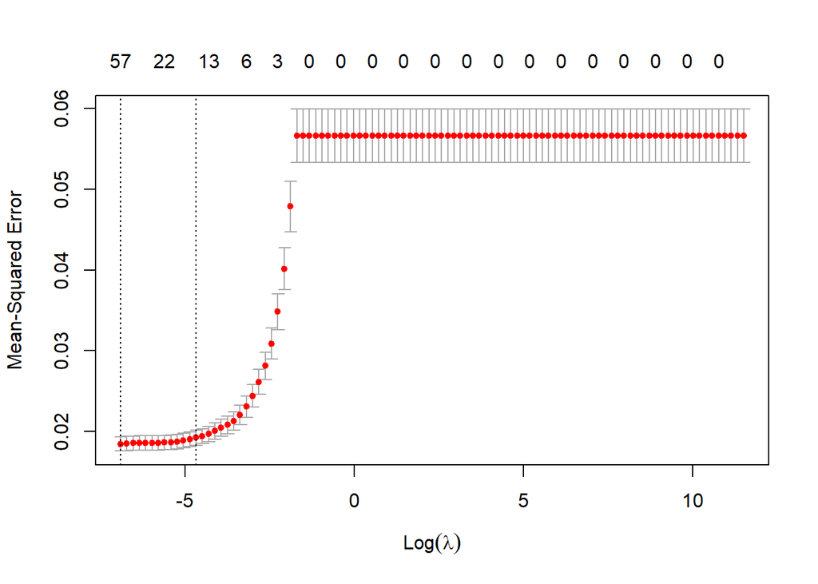

```r
lambdas_to_try <- 10^seq(-3, 5, length.out = 100)
lasso_cv <- cv.glmnet(x_train_communities, as.numeric(y_train_communities), alpha = 1, lambda = lambdas_to_try,
                      standardize = TRUE, nfolds = 10)

lambda_cv <- lasso_cv$lambda.min ## Best cross-validated lambda

plot(lasso_cv)
```

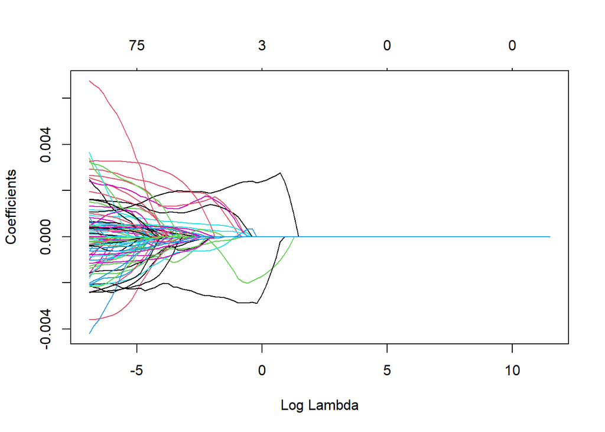

```r
model_cv <- glmnet(x_train_communities, as.numeric(y_train_communities), alpha = 1, lambda = lambda_cv, standardize = TRUE)
y_hat_cv <- predict(model_cv, x_train_communities)
ssr_cv <- t(as.numeric(y_train_communities) - as.numeric(y_hat_cv)) %*% (as.numeric(y_train_communities) - as.numeric(y_hat_cv))
rsq_lasso_cv <- cor(as.numeric(y_train_communities), y_hat_cv)^2

res <- glmnet(x_train_communities, as.numeric(y_train_communities), alpha = 1, lambda = lambdas_to_try, standardize = FALSE)


plot(res, xvar = "lambda")
```

This graph shows how increasing lambda shrinks the coefficients.Each line shows coefficients for one variables, for different lambdas.The higher the lambda, the more the coefficients are shrinked towards zero.

```r
set.seed(105)

regression_tree <- function(i,j){
  tree<-rpart(Class~.,data = communities_train,control = rpart.control(minbucket=i,cp=j),method = "anova")
  rpart.plot(tree,box.palette = "RdBu",shadow.col = "gray",nn=TRUE)
  plotcp(tree)
  pred<-predict(tree,communities_test)

  rss <- sum((pred - communities_test$Class) ^ 2)
  tss <- sum(((communities_test$Class) - mean(communities_test$Class)) ^ 2)
  rsq <- 1 - (rss/tss)
  print(rsq)
}
```

```r
one <- regression_tree(1,0.01)
```

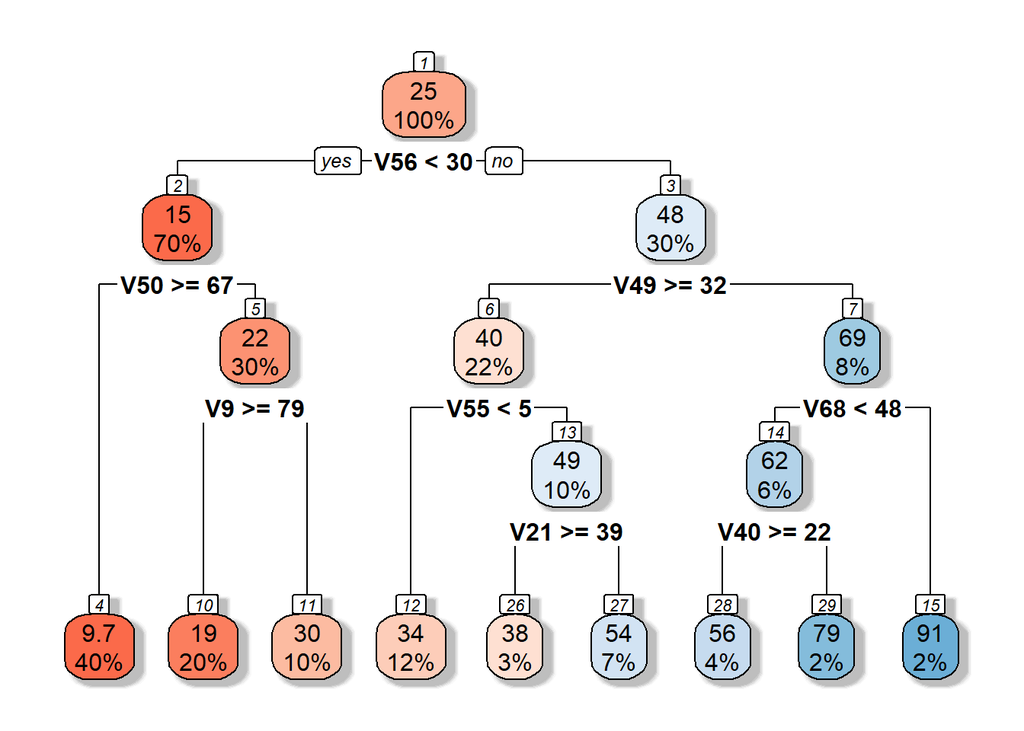

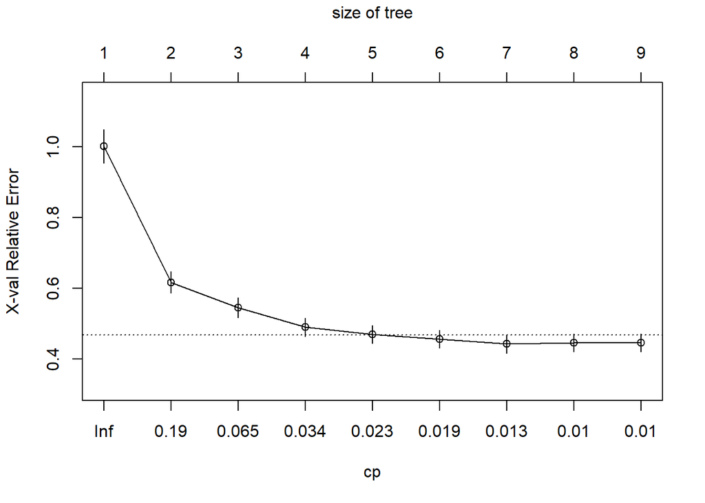

```
## [1] 0.5459307
```

```r
two <- regression_tree(1,0.005)
```

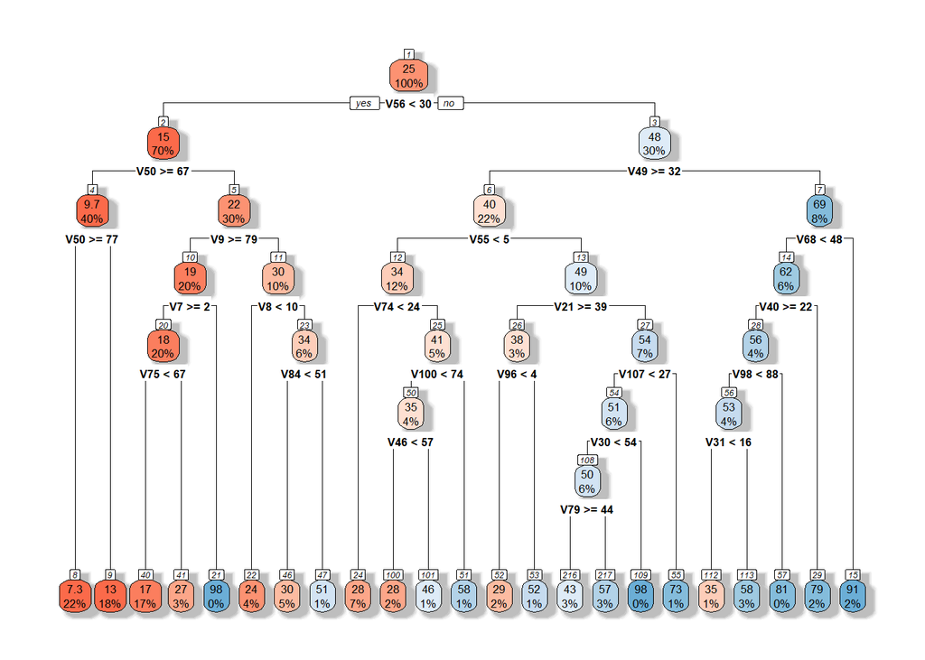

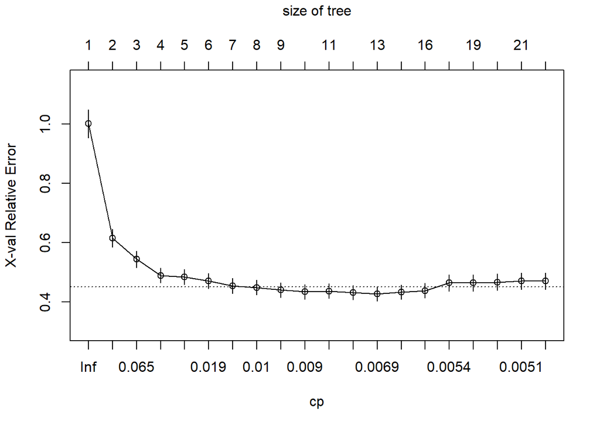

```
## [1] 0.5503303
```

```r
three <- regression_tree(100,0.01)
```

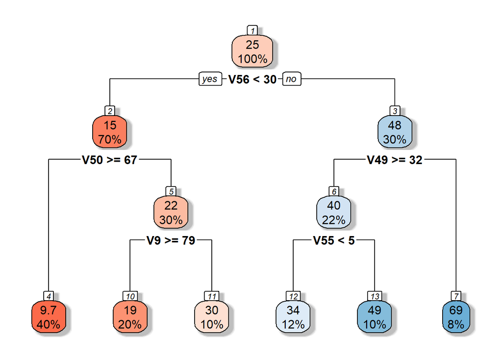

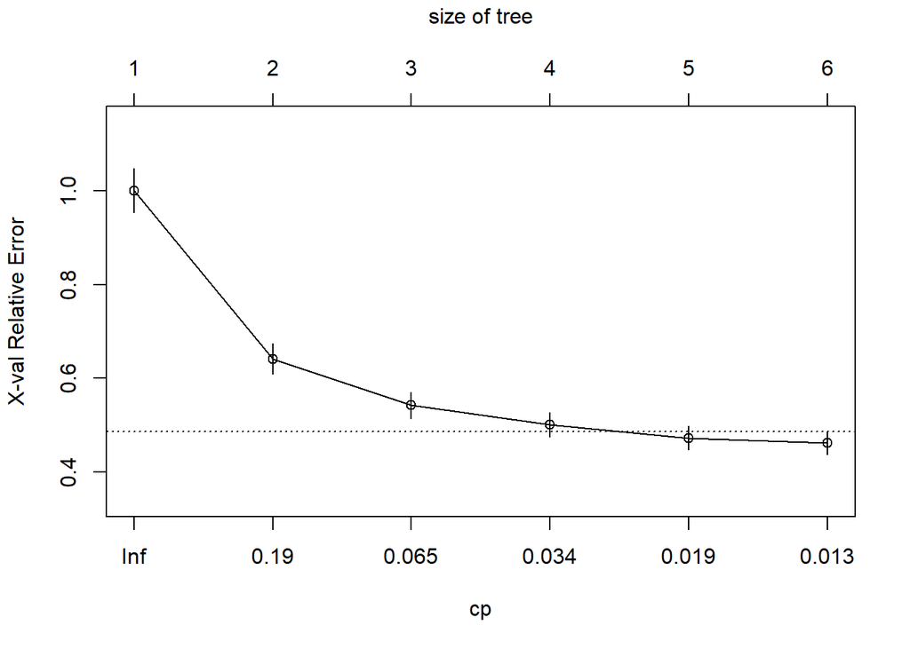

```
## [1] 0.574084
```

```r
four <- regression_tree(100,0.005)
```

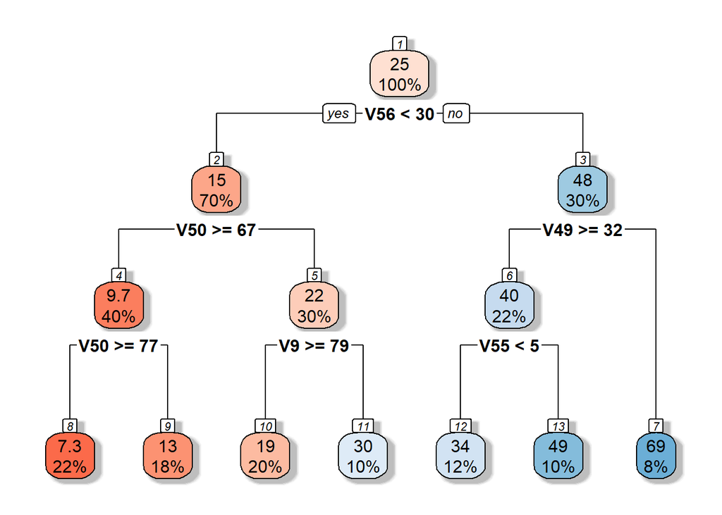

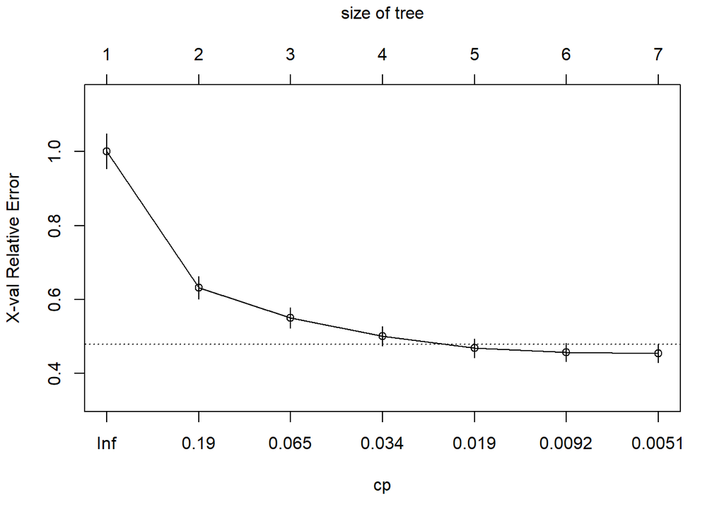

```
## [1] 0.5757557
```

```r
set.seed(105)

rf <- function(i){
  rf<-randomForest(Class~.,data=communities_train,proximity=TRUE,mtry=i)
  plot(rf)

  pred<-predict(rf,communities_test)

  rss <- sum((pred - communities_test$Class) ^ 2)
  tss <- sum((communities_test$Class - mean(communities_test$Class)) ^ 2)
  rsq <- 1 - (rss/tss)
  print(rsq)
}
```

```r
one <- rf(5)
```

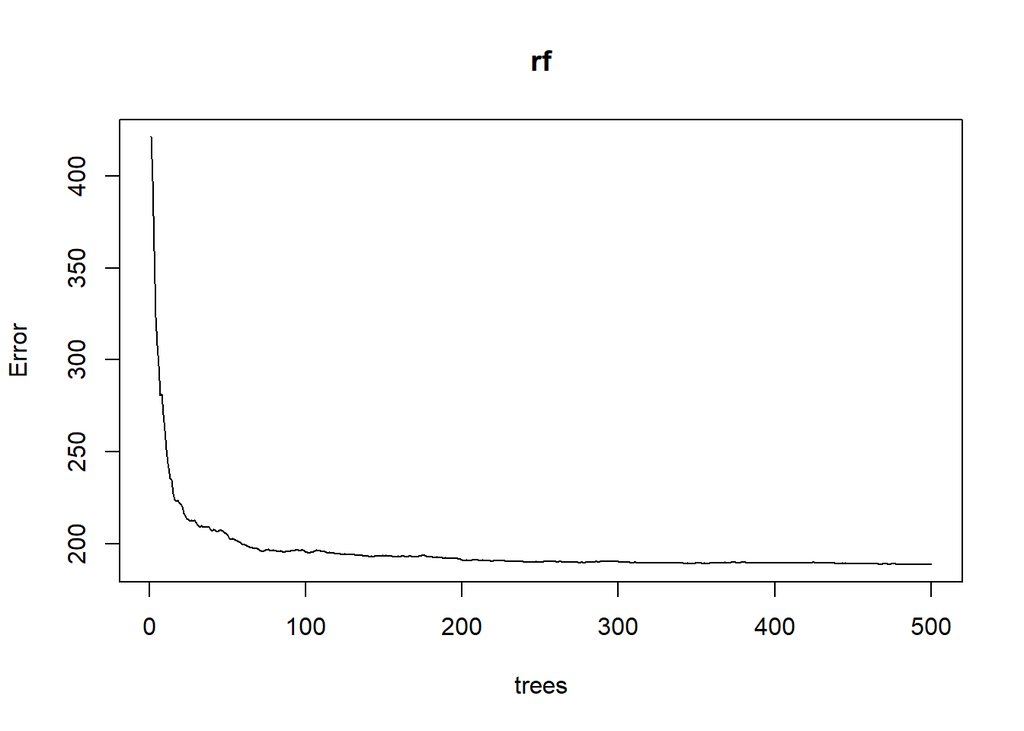

```
## [1] 0.6668366
```

```r
two <- rf(8)
```

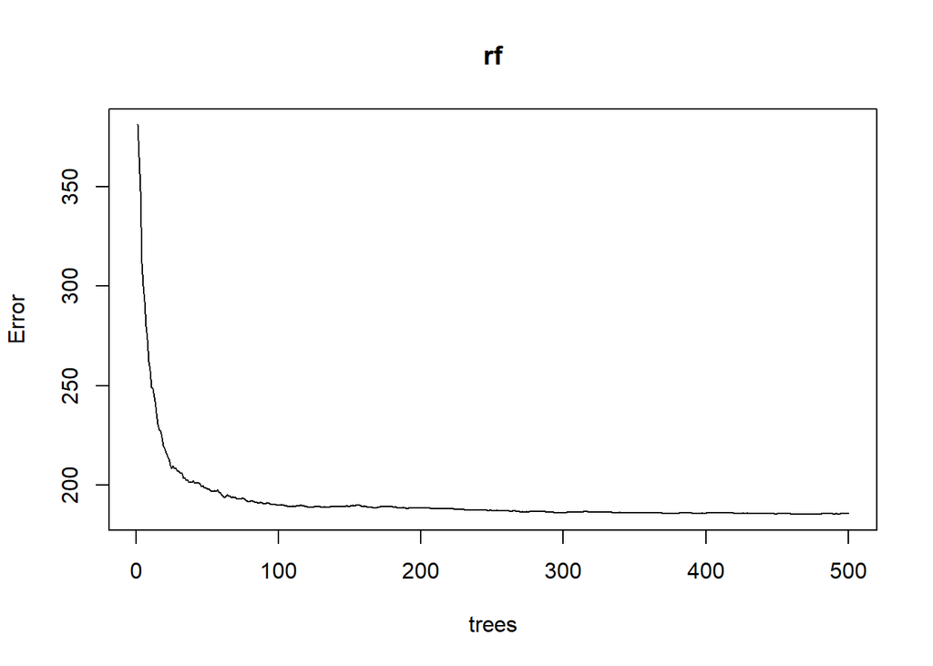

```
## [1] 0.6702427
```

```r
three <- rf(10)
```

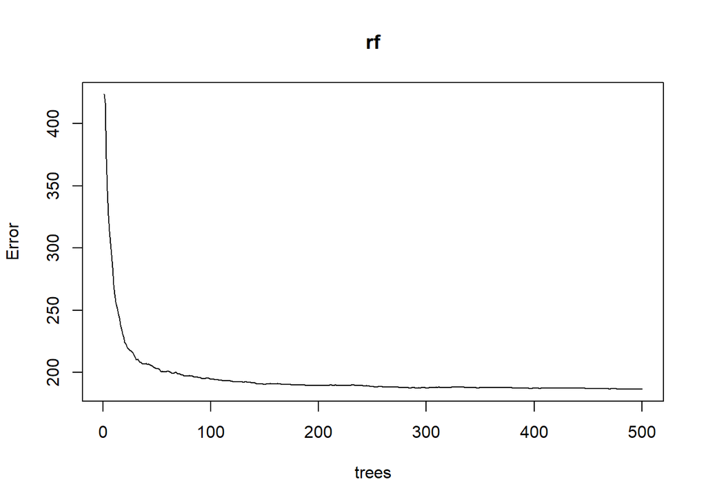

```
## [1] 0.6718895
```

```r
four<- rf(15)
```

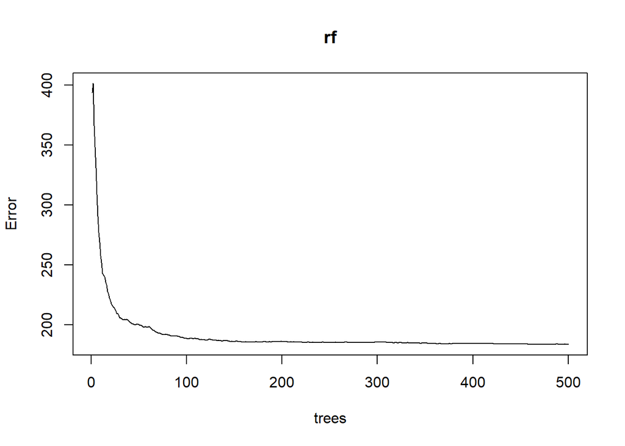

```
## [1] 0.6726833
```

```r
set.seed(123)

sgb<-gbm(Class~.,data = communities_train,distribution="gaussian",cv.folds = 3)
sgb
```

```
## gbm(formula = Class ~ ., distribution = "gaussian", data = communities_train,
##     cv.folds = 3)
## A gradient boosted model with gaussian loss function.
## 100 iterations were performed.
## The best cross-validation iteration was 94.
## There were 122 predictors of which 41 had non-zero influence.
```

```r
pred<-predict(sgb,communities_test,n.trees = 100)

rss <- sum((pred - communities_test$Class) ^ 2)
tss <- sum((communities_test$Class - mean(communities_test$Class)) ^ 2)
rsq <- 1 - (rss/tss)
rsq
```

```
## [1] 0.6537815
```

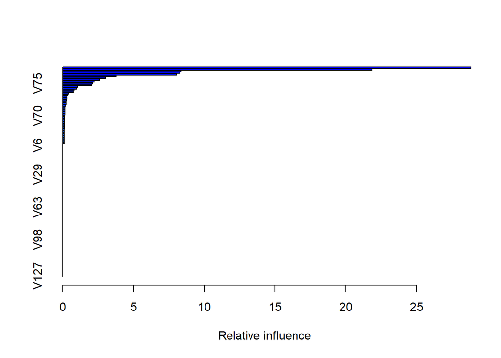

```
##       var    rel.inf
## V56   V56 28.8216279
## V50   V50 21.8612077
## V9     V9  8.3559064
## V55   V55  8.2674259
## V49   V49  8.0372585
## V74   V74  3.7914994
## V47   V47  3.0331540
## V96   V96  2.6012783
## V46   V46  2.2434022
## V75   V75  2.1408294
## V21   V21  2.0716581
## V80   V80  1.0562420
## V34   V34  0.9794774
## V77   V77  0.8133621
## V78   V78  0.7566053
## V8     V8  0.4384383
## V35   V35  0.3523329
## V57   V57  0.2875535
## V126 V126  0.2822534
## V107 V107  0.2761617
## V91   V91  0.2490562
## V32   V32  0.2354880
## V97   V97  0.2137373
## V103 V103  0.1581571
## V83   V83  0.1543436
## V25   V25  0.1517771
## V95   V95  0.1496737
## V108 V108  0.1489419
## V70   V70  0.1471233
## V44   V44  0.1442055
## V114 V114  0.1349292
## V100 V100  0.1349232
## V23   V23  0.1308123
## V42   V42  0.1282964
## V27   V27  0.1268689
## V51   V51  0.1252279
## V120 V120  0.1208142
## V94   V94  0.1195693
## V122 V122  0.1155730
```

[output cut: 68 more lines]

```
## V109 V109  0.0000000
## V110 V110  0.0000000
## V111 V111  0.0000000
## V112 V112  0.0000000
## V113 V113  0.0000000
## V115 V115  0.0000000
## V116 V116  0.0000000
## V117 V117  0.0000000
## V118 V118  0.0000000
## V119 V119  0.0000000
## V121 V121  0.0000000
## V123 V123  0.0000000
## V124 V124  0.0000000
## V125 V125  0.0000000
## V127 V127  0.0000000
```

```r
summary(sgb)
```

## 5.References

https://www.datacamp.com/ https://www.kaggle.com/ http://zevross.com/blog/2017/09/19/predictive-modeling-and-machine-learning-in-r-with-the-caret-package/ https://blog.revolutionanalytics.com/2014/09/comparing-models-in-r.html